# Région Grand Est

JcB

02/02/2017

# Etude de la nouvelle Région Grand Est (RGE)

Pour identifier les départements concernés, on part de la France défnie as l’INSEE:

[output not shown]

```
Checking rgeos availability: TRUE
```

# Exploitation

La RGE compte 10 départements:

- Ardennes 08
- Aube 10
- Marne 51
- Haute Marne 52
- Meurthe et Moselle 54
- Meuse 55
- Moselle 57
- Bas-Rhin 67
- HautRhin 68
- Vosges 88

Soit 5196 communes. Les coordonnées sont indiquées en Lambert93 (conformes au JO). Il existe près de 5000 projections cartographiques. Deux sont utilsées en France:

- la projection conique conforme de Lambert ou Lambert93 qui est la seule légale en France et qui est utilisée par l’IGN et l’INSEE. Les distances sont indiquées en mètres.
- la projection WSG84 utilisée par Googlemap et OpenStreetMap où les distances sont données en Longitude et latitude.

Le fichier ght3 (spatialPolygonsDataFrame) permet de dessiner la RGE par commune, département ou GHT.

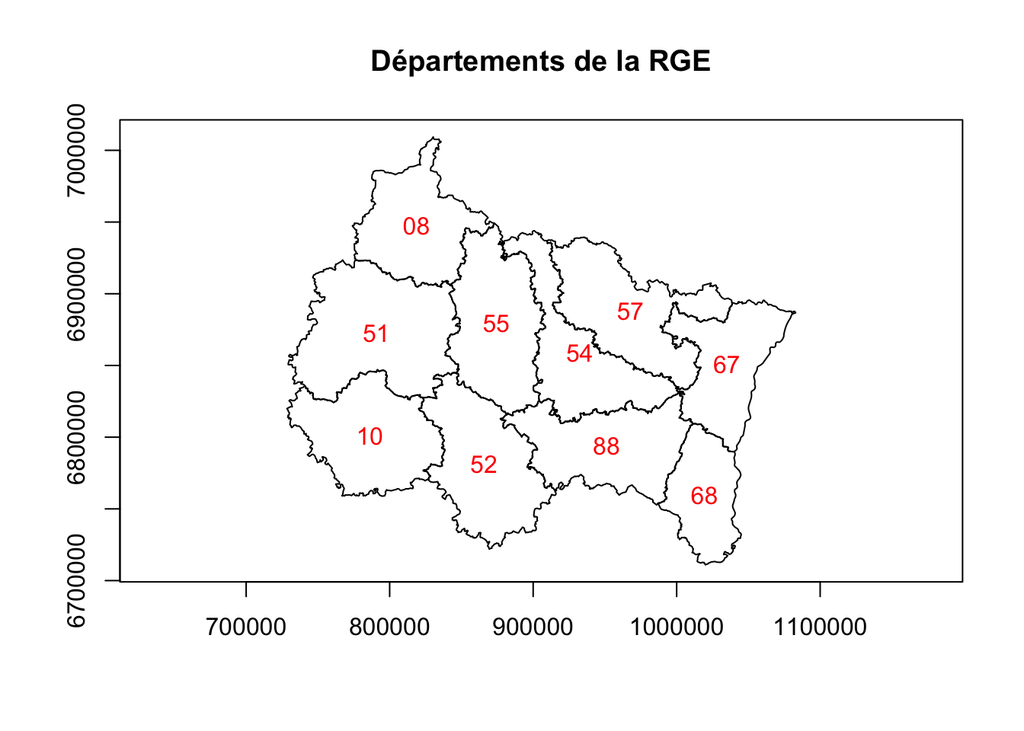

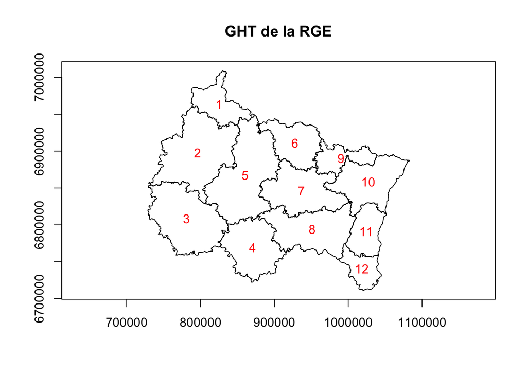

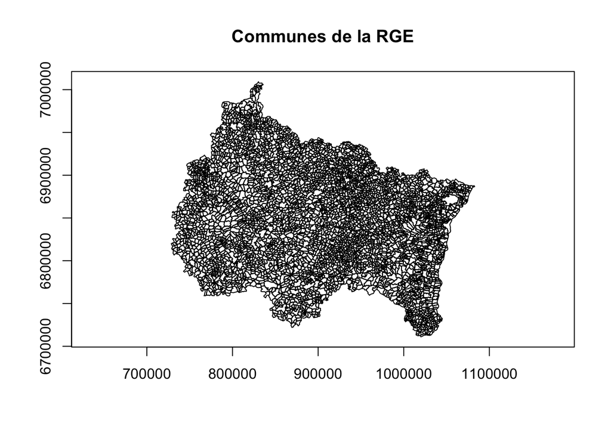

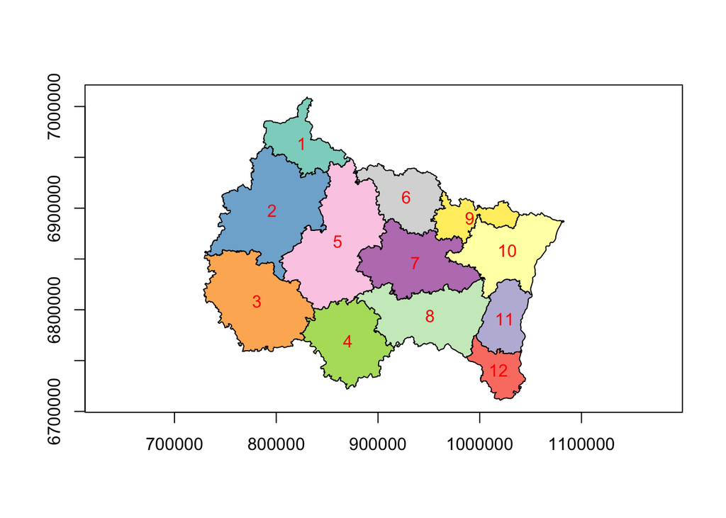

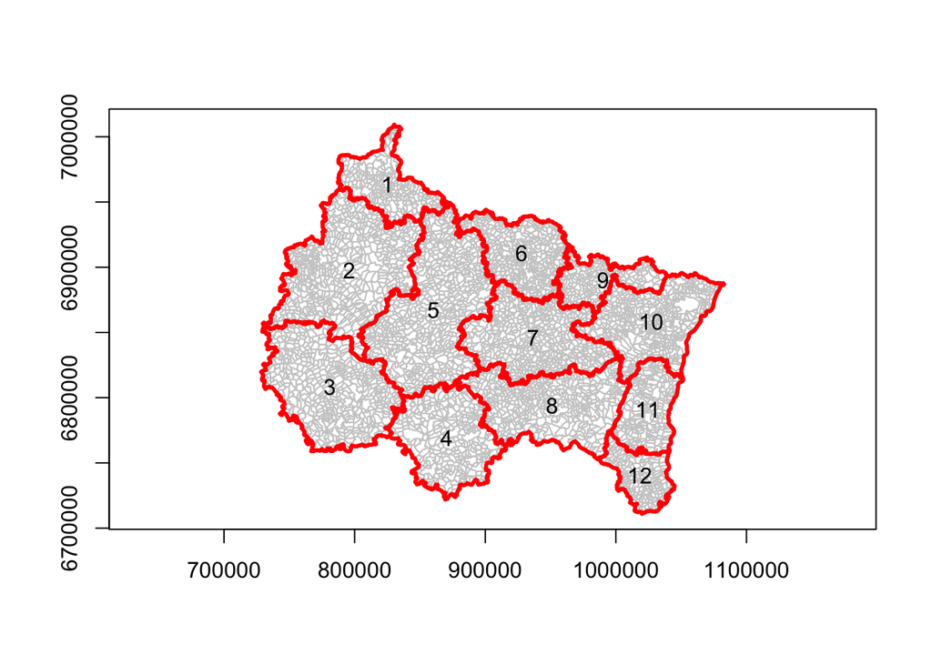

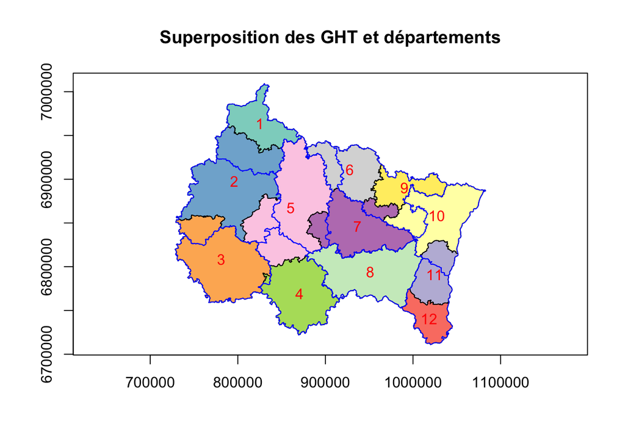

```r
# superposition des GHT et départements
coul <- brewer.pal(n=12, name = "Set3")
plot(ght3, col = coul, axes = TRUE, main = "Superposition des GHT et départements")
b <- coordinates(ght3)
text(b, names(ght3), col = "red")
plot(dep2, border = "blue", add = TRUE)
```

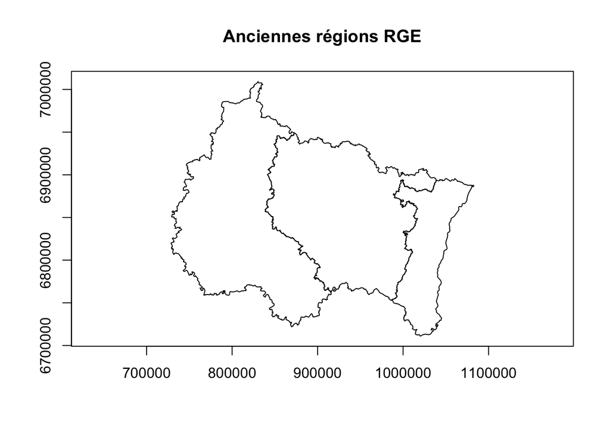

```r
# anciennes régions
# load("RGE-Description/ght3.Rdata")
 load("ght3.Rdata")
ght3$ANC.REG <- NA
ght3$ANC.REG[ght3$CODE_DEPT == 67 | ght3$CODE_DEPT == 68] <- "ALSACE"
ght3$ANC.REG[ght3$CODE_DEPT == 54 | ght3$CODE_DEPT == 55 | ght3$CODE_DEPT == 57 | ght3$CODE_DEPT == 88] <- "LORRAINE"
ght3$ANC.REG[ght3$CODE_DEPT == '08' | ght3$CODE_DEPT == 10 | ght3$CODE_DEPT == 51 | ght3$CODE_DEPT == 52] <- "CHAMPAGNE-ARDENNE"
rge.anc.reg <- unionSpatialPolygons(ght3, IDs = ght3@data$ANC.REG)
plot(rge.anc.reg, axes = T, main = "Anciennes régions RGE")
```

# Villes principales

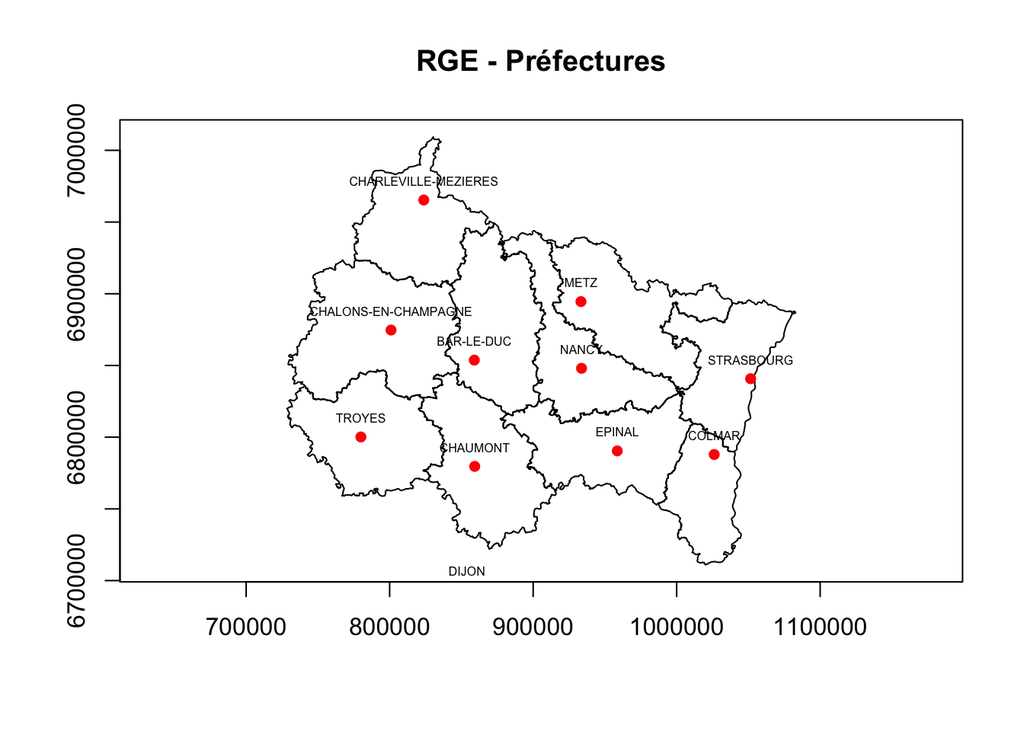

```r
load("../GHT/contour_departements.Rda") # dep2
load("../GHT/ght.Rda") # ght

x <- coordinates(ght[ght$STATUT == "Préfecture de département" | ght$STATUT == "Préfecture de région",])
y <- ght[ght$STATUT == "Préfecture de département" | ght$STATUT == "Préfecture de région", "NOM_COM"]
plot(dep2, axes = TRUE, main = "RGE - Préfectures")
points(x, col = "red", pch = 16)
text(x, as.character(y$NOM_COM), cex = 0.5, pos = 3)
```

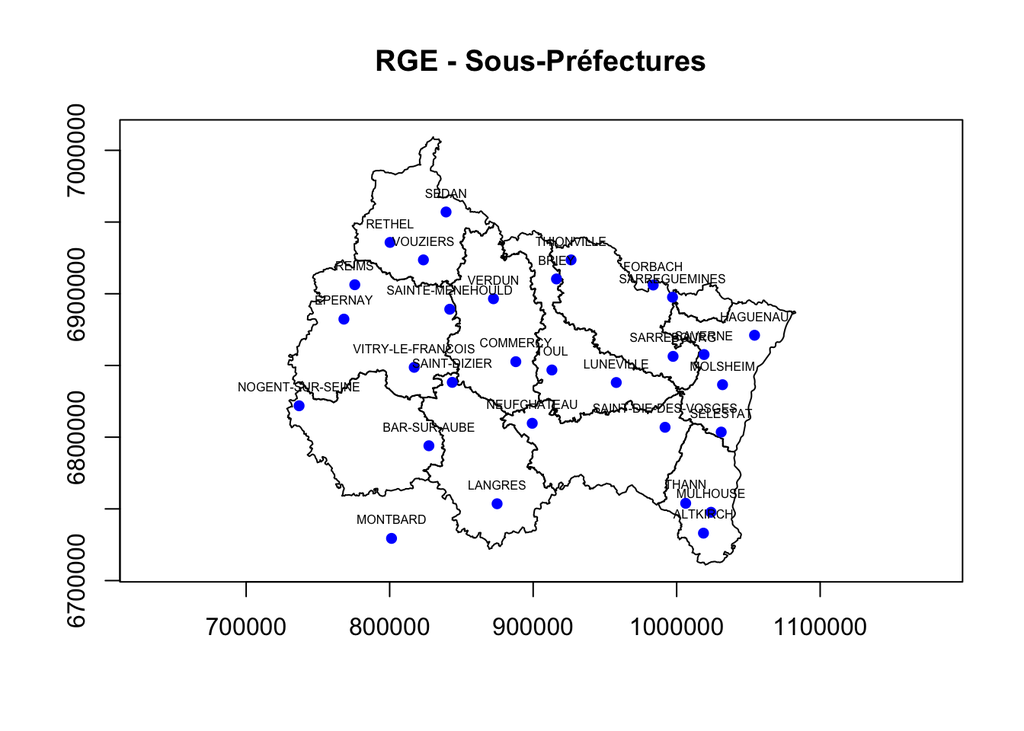

```r
# sous-préfecture
x <- coordinates(ght[ght$STATUT == "Sous-préfecture",])
y <- ght[ght$STATUT == "Sous-préfecture", "NOM_COM"]
plot(dep2, axes = TRUE, main = "RGE - Sous-Préfectures")
points(x, col = "blue", pch = 16)
text(x, as.character(y$NOM_COM), cex = 0.5, pos = 3)
```

# POPULATION

```r
# load("RGE-Description/ght3.Rdata")
 load("ght3.Rdata")

# population par département
pop.dep <- tapply(ght3$POPULATION, factor(ght3$CODE_DEPT), sum)
pop.dep
```

```
     08      10      51      52      54      55      57      67      68
 280907  306581  569999  181521  731004  192094 1046873 1109460  758723
     88
 375226
```

```r
# population par ght
pop.ght <- tapply(ght3$POPULATION, ght3$GHT, sum)
pop.ght
```

```
      1       2       3       4       5       6       7       8       9
 224185  551539  332951  114153  284520  801873  612150  375226  322407
     10      11      12
1041847  408501  483036
```

```r
# population totale
sum(pop.ght)
```

```
[1] 5552388
```

# Hôpitaux-SU de la région grand est

On récupère les fichiers correspondants dans le dossier **/Users/jean-claudebartier/Documents/Resural/Stat Resural/RPU_Doc/RPU_Carto-Pop-Alsace/Cartographie/Structures_Urgence_FEDorU**. Il y a 3 fichiers au format csv correspondant aux anciennes régions.

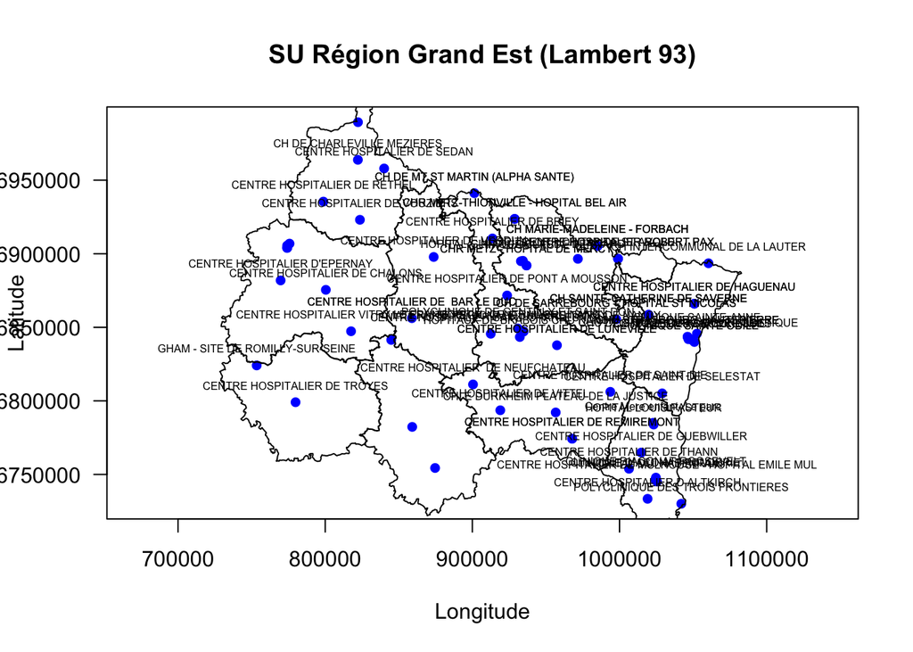

```r
path = "/Users/jean-claudebartier/Documents/Resural/Stat Resural/RPU_Doc/RPU_Carto-Pop-Alsace/Cartographie/Structures_Urgence_FEDorU/"
a <- paste0(path, "Structures d'urgence_Als.csv")
b <- paste0(path, "Structures d'urgence_Lor.csv")
c <- paste0(path, "Structures d'urgence_CA.csv")

a2<-read.csv(a, skip = 1)
b2<-read.csv(b, skip = 1)
c2<-read.csv(c, skip = 1)
hopRge <- rbind(a2,b2,c2)
# On ne cnserve que les colonnes ayant un intéret. Les col. 12 et 13 contiennent latitude et longitude en WS84.
hopRge <- hopRge[, c(2,3,7,8,9,10,15,16,20,21)]

d2 <- hopRge
# on transforme mes virgules en points puis en numéric
d2$Longitude <- as.numeric(gsub(",",".", d2$Longitude))
d2$Latitude <- as.numeric(gsub(",",".", d2$Latitude))
coordinates(d2) = ~ Longitude + Latitude
proj4string(d2) = CRS("+proj=longlat +datum=WGS84")
# Reprojeter au format Lambert 93
# -------------------------------
# EPSG:2154 Lambert 93
newProj = CRS("+proj=lcc +lat_1=49 +lat_2=44 +lat_0=46.5 +lon_0=3 +x_0=700000 +y_0=6600000 +ellps=GRS80 +towgs84=0,0,0,0,0,0,0 +units=m +no_defs")
su_alca_L93 <- spTransform(d2, newProj)

plot(su_alca_L93, xlab = "Longitude", ylab = "Latitude", axes = TRUE, las = 1, main = "SU Région Grand Est (Lambert 93)" , pch = 16, col= "blue")
plot(dep2, add = TRUE)
x <- coordinates(su_alca_L93[su_alca_L93$Nom.établissement,])
y <- su_alca_L93[su_alca_L93$Nom.établissement,"Nom.établissement"]
text(x, as.character(y$Nom.établissement), cex = 0.5, pos = 3)
```